# Simulation Design and Modeling Strategy

The Influence of Reviewer Expertise and Engagement on Peer Review of Grants

Author

Sam Harper & Arijit Nandi

Published

2026-09-04

# 1 Overview

This is a design and validation exercise for a project that aims to assess how reviewer engagement and expertise may affect post-discussion grant scores during CIHR peer review. Given the restrictive nature of CIHR funding data, this document lays out the data-generating process we believe is similar to CIHR’s Project Grant peer review, the model we intend to fit against it, and evidence that the models we will use can actually recover simulated effects.

It is not a full pre-analysis plan (no pre-specified hypotheses), but it’s close in spirit, and a subsequent revision could become one.

## 1.1 Research aims

1. **Aim 1** – How do reviewer expertise (self-described: high/medium/low/not enough) and engagement (assigned reviewer vs. non-reviewing panelist) affect the impact of panel discussion on scores?
2. **Aim 2** – Do these effects differ by applicant characteristics, namely gender or career stage?
3. **Aim 3** (exploratory) – How would alternative funding-decision schemes (e.g. reweighting by engagement, partial randomization near the funding threshold) compare to the status quo?

## 1.2 Project Scheme review process

- The 3 assigned reviewers read the application and score it. At the meeting (and *before* any discussion), they they give their initial scores.
- R1 gives a summary and strengths/weaknesses. R2/R3 add any additional points of disagreement, followed by discussion among the entire panel.
- After discussion the 3 assigned reviewers agree on a **consensus score**.
- All panel members (including the 3 reviewers) then submit a **final score**. Reviewers are not bound to their own consensus number; they can move too.
- The final score must fall within **±0.5** of the consensus score, and is entered to **one decimal place**.
- The (equally weighted) average of final scores across all panel members feeds the funding decision.

## 1.3 Data structure

We’re assuming a three-level structure: CIHR-established committees, applications nested in committees, and panel members nested in committees (crossed with applications, since each member reviews many applications within a cycle). Based on recent Project Grant committee sizes (cite webpage?), our working numbers are roughly 50 committees, but we allow the number of applications across committees to vary based on CIHR documentation, and simulate the number of applications proportionally (with some variance)

CIHR’s Funding Analytics Team confirmed by email which fields are actually extractable for a data pull, versus fields that can only ever be touched by a CIHR analyst running our code in-house on the real data under the same remote-execution workflow, without a dummy-data rehearsal step first, grouped by the level each field is measured at:

Table 1

CIHR field-by-field data availability, by level

| Indicator | Availability |
| --- | --- |
| Application | Application |
| Committee number | Extractable |
| Application number | Extractable |
| Funding result | Extractable |
| Consensus score | Extractable |
| Resubmission status | Extractable (2023 competition onward only) |
| Keywords/domain | Refused -- identifiability risk |
| Number of investigators | Refused -- identifiability risk |
| Funding requested | Refused -- identifiability risk |
| Applicant | Applicant |
| Prior funding success (binary) | Extractable |
| Gender | In-house only (no dummy data) |
| Career stage | In-house only (no dummy data) |
| Scientific productivity | In-house only -- and unlikely even then |
| Member | Member |
| Member number / cid | Extractable |
| Job (reviewer vs. panelist role) | Extractable |
| Self-declared expertise (High/Medium/Low/Not enough) | Extractable (can be split into binary columns) |
| Score (final/voted score) | Extractable |
| Initial reviewer scores | Extractable |
| Past funding success (binary) | Extractable |
| Conflicts of interest | Extractable (probably -- bundled with expertise data) |
| Gender | In-house only (no dummy data) |
| Experience/tenure as a reviewer (distinct from self-declared expertise above; measurement TBD) | In-house only (no dummy data) |

CIHR field-by-field data availability, by level

**Applicant gender and career stage – Aim 2’s entire basis – are not extractable**, and won’t appear even in CIHR’s own distribution-matched dummy data. That constraint is why this document exists: the simulation below is the only rehearsal Aim 2’s code gets before it runs once, unsupervised, on real data.

# 2 Modeling Strategy

## 2.1 Primary outcome(s)

The primary Aim 1 outlined above is to assess how *changes* from the initial consensus score to the final review scores (after discussion) may vary with panel expertise and engagement. Thus, rather than our primary outcome being the overall application score, we specifically want to model the difference between the consensus score and the final scores.

Let $d_{ijk}$ be the final score minus the consensus score, for the $i$th panel member on the $j$th application in the $k$th committee:

$$d_{ijk} = \text{final score}_{ijk} - \text{consensus score}_{jk}$$

Our interest is in modeling $d_{ijk}$ directly, rather than modeling the final score with consensus score as a covariate, for three reasons:

1. **Point mass at zero.** We hypothesize that most or many members will go with the consensus score, which leads to a probability mass either at the consensus (if you modeled the score) or a mass at zero if you model the difference. A member who doesn’t move from consensus has $d_{ijk}=0$ regardless of which application they’re scoring. So even if you model the final score conditional on the consensus you will still have a spike, just relocated to wherever a given application’s consensus happened to land. Differencing standardizes the spike’s location (at zero) across every application and makes a shared two-part model more feasible.
2. **Avoids some sources of confounding.** The consensus score is constant across everyone in the committee and reflects both the reviewer’s and the application’s initial “true quality” signal. Subtracting it off removes anything that’s shared by every member evaluating the same application (committee identity, application quality, etc.), leaving only the within-application variation across panel members as what’s left to explain. If some committees have both higher consensus scores and a different mix of reviewer expertise then consensus and ‘expertise’ are correlated across applications. Differencing eliminates this potential bias since the coefficient on consensus isn’t estimated at all.
3. **Matches the actual research question.** Aim 1 is about the *change from consensus* induced by discussion, not the *level* of the final score (driven mostly by application quality). Since it is simple to recover the final score like $\text{final score} = \text{consensus} + d_{ijk}$, anything Aim 3 needs at the score level for funding-decision simulations can be reconstructed downstream.

## 2.2 Estimand of interest

Our main quantity of interest in this project is the value that a given committee member’s score differential from the consensus ($d_{ijk}$) would take if a particular reviewer characteristic (role or experience) were set to a specific value, averaged over the entire population of panel members, applications, and committees. We can write an example of, say, the difference between differential scores for a given member-application pairing if that member were assigned to be a panelist or a reviewer:

$$\underbrace{\frac{1}{IJK}\sum^{K}_{k=1}\sum^{J}_{j=1}\sum^{I}_{i=1}}_{\substack{\text{Mean over members } i\text{,} \\ \text{applications } j\text{,} \\ \text{and committees } k}} \underbrace{\left(d_{ijk}(1) - d_{ijk}(0)\right)\vphantom{\sum^{K}_{k=1}\sum^{J}_{j=1}\sum^{I}_{i=1}}}_{\substack{\text{Score if assigned} \\ \text{to panelist(1)} \\ \text{or reviewer(0)}}}$$

Leaving aside for the moment the assumptions needed to credibly estimate this quantity, the specific data generating process for score deviations leads to challenges, since the distribution of this outcome depends on two processes: 1) whether a given member deviates from the consensus score; and 2) how large that deviation might be. Estimating these effects across the whole population of applications leads to the intuition for a two-part model.

## 2.3 Two-part model

We expect $d_{ijk}$ to have a spike at exactly zero (members who simply adopt the consensus score) plus variation among those who depart from it. So the outcome is split into two linked models:

1. **Did this member deviate at all?** A binary/logistic model on $1[d_{ijk} \neq 0]$.
2. **If they deviated, by how much?** A model for the (signed) magnitude, conditional on deviating.

Estimating the expected value of the both parts across the entire population of reviewers (not just those that deviate from consensus) recovers the effect in the entire sample. This is akin to a ‘hurdle’ type model (Mullahy 1986) that combines a binary outcome and a magnitude estimate for non-zero outcomes.

$$E[d_{ijk}] = \underbrace{P(\text{deviate})}_{\substack{\text{Part 1: any} \\ \text{deviation at all}}}
\times
\underbrace{E[\text{magnitude} \mid \text{deviate}]}_{\substack{\text{Part 2: size} \\ \text{given deviation}}}$$

## 2.4 Model specification (Aim 1)

We adopt a Bayesian modeling approach and model the binomial outcome of whether or not a member deviated as a function of their engagement with the application (reviewer vs. panelist) and their self-declared expertise to review (high, medium, low, none). In our specification below $D_{ijk}$ is 1 for those who deviated, and we include random effects for committees ($\gamma_{cmte[k]}$), members ($\alpha_{mem[i]}$), and applications ($\beta_{app[j]}$). For the fixed effects $\delta$ is the effect of being a panelist vs. reviewer, and $\zeta$ captures the suite of effects for the expertise indicators ($\textbf{Exp}_{ij}$)

$$\begin{array}{rclr}
D_{ijk} & \sim & \text{Binomial}(1, p_{ijk}) & \text{[likelihood]} \\
\text{logit}(p_{ijk}) & = & \alpha_{mem[i]} + \gamma_{cmte[k]} + \beta_{app[j]} + \delta\,\text{Panelist}_{ijk} + \zeta \textbf{Exp}_{ij} & \text{[linear model for log odds]} \\
& & & \\
\alpha_{mem[i]} & \sim & \text{Normal}(\bar\alpha, \sigma_\alpha) & \text{[prior for member intercepts]} \\
\gamma_{cmte[k]} & \sim & \text{Normal}(0, \sigma_\gamma) & \text{[prior for committee intercepts]} \\
\beta_{app[j]} & \sim & \text{Normal}(0, \sigma_\beta) & \text{[prior for application intercepts]} \\
(\delta, \zeta) & \sim & \text{Normal}(0, 0.5) & \text{[prior for fixed effects]} \\
\bar\alpha & \sim & \text{Normal}(0, 1.0) & \text{[prior for average member]} \\
(\sigma_\alpha, \sigma_\gamma, \sigma_\beta) & \sim & \text{Exponential}(1) & \text{[prior for standard deviations]} \\
\end{array}$$

Bayesian models require priors on all parameters, and we generally plan to use weakly regularizing priors that allow for a wide range of potential effects but that are generally skeptical of effects of large magnitude. Below we show distributions that helped frame our decision. For the overall probability of deviating the Normal(0, 1.0) prior (green line in top plot) provides a generally wide possibility of the probability of deviating (95% of the probability mass is between 14% and 88% deviating), and a Normal(0, 0.5) for the beta coefficients puts 95% of the probability mass on differences in the probability of deviating of +/- 20 percentage points (i.e., it is quite skeptical of very large effect sizes).

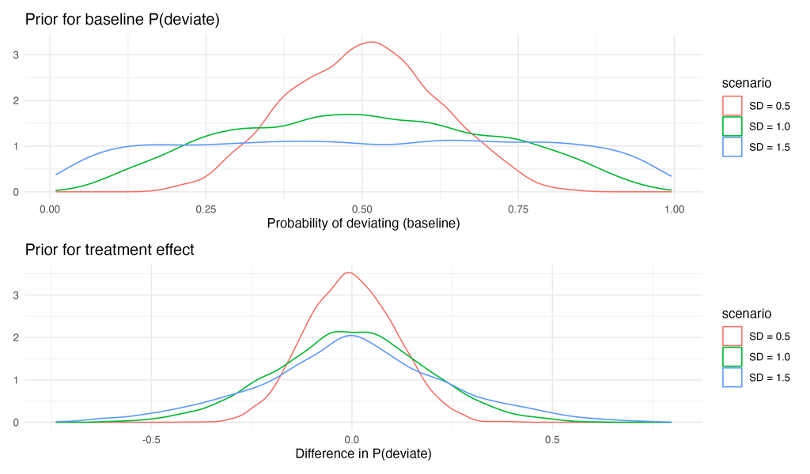

Figure 1: Hypothetical priors for deviation model

## 2.5 Model specification: magnitude, given a deviation

$$\begin{array}{rclr}
M_{ijk} \mid D_{ijk}=1 & \sim & \text{Cumulative}(\eta_{ijk}, \kappa_{ijk}, \boldsymbol\tau) & \text{[likelihood, 10 ordered categories]} \\
P(M_{ijk} \le c) & = & \text{logit}^{-1}\big(\kappa_{ijk}(\tau_c - \eta_{ijk})\big) & \text{[cumulative-logit link]} \\
\eta_{ijk} & = & \alpha_{mem[i]} + \gamma_{cmte[k]} + \beta_{app[j]} + \delta\,\text{Panelist}_{ijk} + \zeta \textbf{Exp}_{ij} & \text{[location]} \\
\log(\kappa_{ijk}) & = & \delta_0^{disc} + \delta_1^{disc}\,\text{Panelist}_{ijk} & \text{[role-specific discrimination]} \\
& & & \\
\alpha_{mem[i]} & \sim & \text{Normal}(0, \sigma_\alpha) & \text{[prior for member intercepts]} \\
\gamma_{cmte[k]} & \sim & \text{Normal}(0, \sigma_\gamma) & \text{[prior for committee intercepts]} \\
\beta_{app[j]} & \sim & \text{Normal}(0, \sigma_\beta) & \text{[prior for application intercepts]} \\
\tau_c & \sim & \text{Normal}(0, 1.5), \ c = 1,\ldots,9 & \text{[prior for thresholds]} \\
(\delta, \zeta) & \sim & \text{Normal}(0, 0.5) & \text{[prior for location fixed effects]} \\
(\delta_0^{disc}, \delta_1^{disc}) & \sim & \text{Normal}(0, 1) & \text{[prior for discrimination effects]} \\
(\sigma_\alpha, \sigma_\gamma, \sigma_\beta) & \sim & \text{Exponential}(1) & \text{[prior for standard deviations]} \\
\end{array}$$

**Why ordinal (`cumulative()`), not categorical/multinomial?** The 10 magnitude levels aren’t just index labels – they’re the literal numeric ordering of `final_score - consensus` ($-0.5 < -0.4 < \ldots < -0.1 < 0.1 < \ldots < 0.5$), and treating them as categorical would throw that structure away, treating “+0.3” and “-0.4” as no more related to each other than either is to “+0.1”. It also matches the actual data-generating mechanism: this is a continuous quantity (a truncated-normal draw) rounded to one decimal place for recording, not 10 qualitatively distinct outcomes – modeling a discretized continuum with an ordinal model, rather than as unordered categories, is the standard match for that kind of measurement. A multinomial model would also need a full separate set of coefficients (role, expertise, every random effect) for each of the 9 non-reference categories – roughly 9x the parameters of the ordinal specification, most poorly identified given how sparse the tail categories are – versus the ordinal model’s single location parameter (and now, a role-specific dispersion parameter) shared across all 10 categories via the threshold structure. That matters substantively too: our actual hypotheses (“panelists’ deviations run larger on average,” “panelists show more spread”) are inherently location/dispersion statements, which only have a natural expression on an ordered scale – a categorical model has no notion of shift or spread at all, just 10 free-floating probabilities from which those would have to be reconstructed post hoc.

One caveat worth flagging: treating the *full signed* scale as a single ordered dimension is a modeling choice, not the only defensible one. It implicitly assumes direction and magnitude of deviation share one underlying continuum, rather than direction being a separate, qualitatively distinct decision (up vs. down) with magnitude nested inside it – the latter is what the alternative three-part model discussed elsewhere (bernoulli direction + ordinal $|\text{magnitude}|$) would assume instead. We think the single-continuum assumption is the more faithful match to how these scores actually arise (one continuous departure from consensus, not “decide direction, then decide how far”), but it is an assumption.

# 3 Simulating

**code/ror-sim-deviate.R – parameters and generative process**

```r
# define parameters
cmte_n = 50          # number of committees

# pool_size (candidate applications per committee, before streamlining)
# varies by committee -- beta-distributed on CIHR's stated [20, 80]
# range -- and mem_n (committee size) is DERIVED from pool_size via a
# workload target, not drawn independently
pool_min = 20
pool_max = 80
target_reviews_per_member = 8
mem_min  = 8         # real range, from CIHR's Fall 2025 committee rosters
mem_max  = 37

b0       = 4.0    # intercept for application's true underlying quality
u0c_sd   = 0.1    # random intercept SD for committee (quality level)
u0a_sd   = 0.3    # random intercept SD for application (quality level)

# signed magnitude of deviation, given deviation occurs, truncated to
# +/- 0.5 (CIHR's stated bound on final vs. consensus score) -- spread
# is now role-dependent, not a single shared value
dev_sd_reviewer = 0.15
dev_sd_panelist = 0.30
dev_min  = -0.5
dev_max  =  0.5

# ... committee/application/member structure (including the pool_size
# -> mem_n derivation), reviewer assignment, and expertise assignment
# omitted here -- see code/ror-sim-deviate.R for the complete script

data <- data |>
  mutate(
    p_dev = plogis(a0 + (a1 * panelist) + (a2 * exp_med) +
      (a3 * exp_low) + (a4 * exp_none)),
    deviated = rbinom(n(), 1, p_dev),
    dev_sd_i = if_else(panelist == 1, dev_sd_panelist, dev_sd_reviewer),
    deviation = if_else(
      deviated == 1,
      round_tenth(rtruncnorm(n(), a = dev_min, b = dev_max,
        mean = dev_bias + u0m_bias, sd = dev_sd_i)),
      0)
  )
```

Every parameter above is at this point just an educated guess and a placeholder, since the point of the simulation is to see whether our modeling approach recovers a known effects, not predictive of what CIHR’s actual numbers will look like.

## 3.1 Simulated data

What did we generate with the parameters above? Figure 2 shows our simulated 50 committees with varying sizes and the number of total and discussed applications. Across the committees the fraction discussed varies from 28.3% to 43.2%. Generally, larger committees end up with more total and more discussed applications.

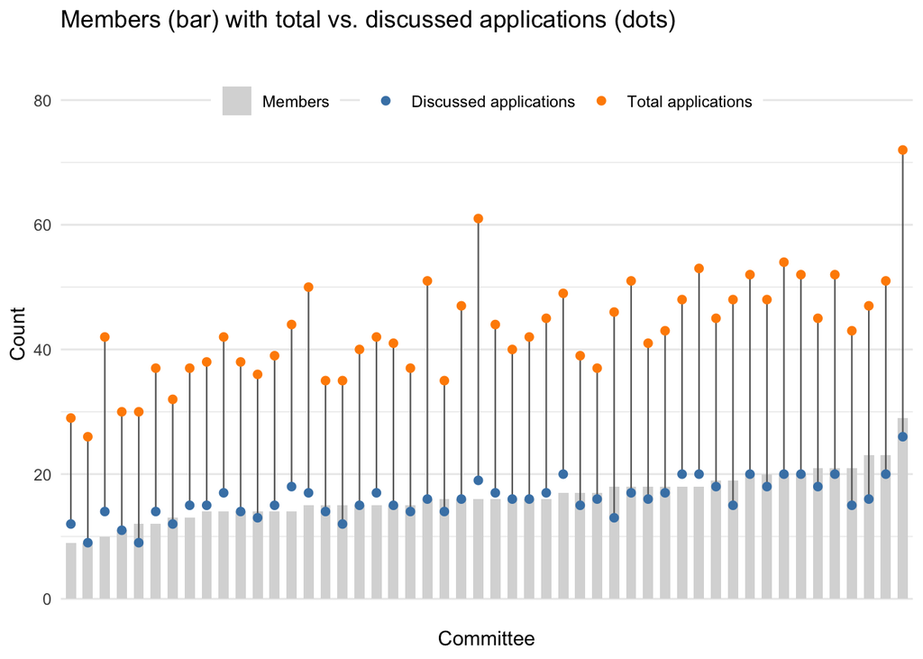

Figure 2: Distribution of committee sizes, total and discussed applications

Figure 3 shows the distribution of initial scores from the three reviewers, the consensus score and then a distribution of overall scores allowing for +/- 0.5 point deviations. Since the likely true consensus scores are not necessarily an average of the 3 reviewer scores (depending on calibration, etc.) we see a small excess in the left tail near 3.5. In practice a consensus score of 3.5 *among discussed applications* is likely more rare, but this seems a reasonable approximation.

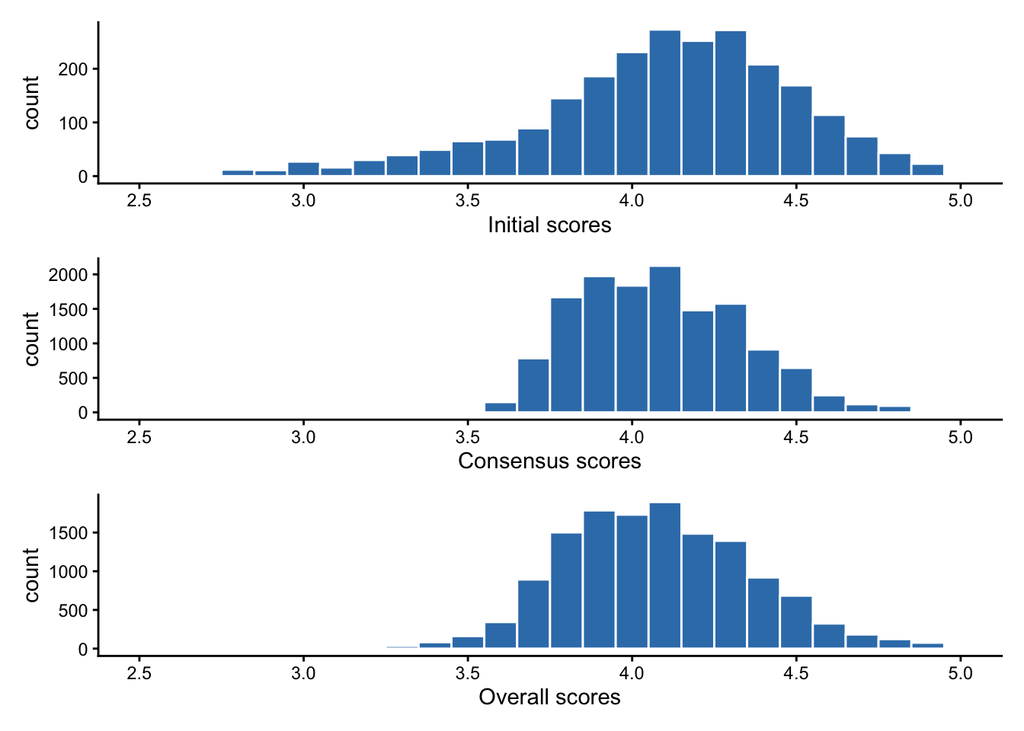

Figure 3: Distribution of simulated intial, consensus, and overall scores

Figure 4 also shows the odd distribution of deviations from the overall consensus score, with a large spike at zero (roughly 2/3rds of committee members going with the consensus):

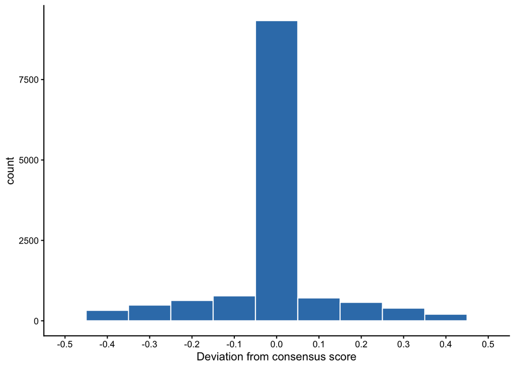

Figure 4: Distribution of deviations from overall consensus scores

Figure 5 shows how our initial simulation incorporates a small degree of variation across committees in the overall scores, as well as the average variation within committees across applications. For the application-level variation we average over committee by within-committee application rank.

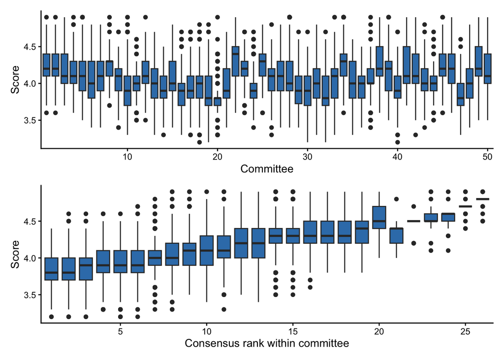

Figure 5: Distribution of score variation by committee and application

## 3.2 Part 1: did this member deviate?

**code/ror-analysis-deviate-model.R – Part 1 (bernoulli)**

```r
m1_deviate <-
  brm(data = d1,
      family = bernoulli(),
      deviated ~ 1 + job + exp + (1 | cmte) + (1 | cid) + (1 | app),
      prior = c(prior(normal(0, 1.0), class = Intercept),
                prior(normal(0, 0.5), class = b),
                prior(exponential(1), class = sd)),
      iter = 2000, warmup = 1000, chains = 4, cores = 4,
      sample_prior = "yes",
      control = list(adapt_delta = 0.95))
```

This model run on the simulated data gives the following estimates, shown in Table 2:

Table 2

Posterior estimates: m1_deviate

| Parameter | Truth | Estimate | Error | 95% CrI Lower | 95% CrI Upper |
| --- | --- | --- | --- | --- | --- |
| Fixed effects (log odds) | Fixed effects (log odds) | Fixed effects (log odds) | Fixed effects (log odds) | Fixed effects (log odds) | Fixed effects (log odds) |
| Intercept | -0.5 | -0.495 | 0.067 | -0.630 | -0.360 |
| Panelist vs. Reviewer | 0.3 | 0.305 | 0.054 | 0.198 | 0.415 |
| Medium vs. High Expertise | -0.3 | -0.259 | 0.072 | -0.399 | -0.123 |
| Low vs. High Expertise | -0.5 | -0.537 | 0.072 | -0.673 | -0.396 |
| None vs. High Expertise | -0.8 | -0.809 | 0.073 | -0.948 | -0.668 |
| Random effects (SD) | Random effects (SD) | Random effects (SD) | Random effects (SD) | Random effects (SD) | Random effects (SD) |
| Application |  | 0.100 | 0.064 | 0.007 | 0.204 |
| Committee Member |  | 0.050 | 0.041 | 0.002 | 0.145 |
| Committee |  | 0.035 | 0.028 | 0.001 | 0.097 |

Estimates from deviation model

From the fixed effects we see that we generally recover the simulated parameters – the ‘true’ treatment effects in the first column are well approximated by our model. The three random-effect SDs are small and estimated with considerable uncertainty; the simulated data-generating process for whether a member deviates (`deviated`) depends only on `job` and `exp`, with no committee-, application-, or member-level heterogeneity built in at that stage (member-level heterogeneity only enters the *magnitude* of deviation, modeled separately in Part 2 below), so this is the expected pattern. We can also generate the estimated absolute probabilities of deviating and how those are affected by `job` and `expertise` using the `marginaleffects` package.

Table 3

Predicted probability of deviation from consensus

| Parameter | P(deviate) | 95% CI Lower | 95% CI Upper |
| --- | --- | --- | --- |
| Overall | Overall | Overall | Overall |
| All members | 0.315 | 0.308 | 0.321 |
| By self-rated expertise | By self-rated expertise | By self-rated expertise | By self-rated expertise |
| High | 0.442 | 0.410 | 0.476 |
| Medium | 0.378 | 0.357 | 0.400 |
| Low | 0.316 | 0.301 | 0.328 |
| Not enough | 0.260 | 0.248 | 0.270 |
| By role | By role | By role | By role |
| Reviewer | 0.265 | 0.247 | 0.282 |
| Panelist | 0.327 | 0.318 | 0.335 |

Marginal effects from deviation model

## 3.3 Part 2: how large, given a deviation?

CIHR scores are entered to one decimal place, so a deviator’s score can only land on one of 10 discrete steps ($\pm0.1 \ldots \pm0.5$ relative to consensus). That’s genuinely ordinal/discrete data, not a continuous quantity with occasional extreme values – a continuous family (`student()`/`gaussian()`) would assign probability to impossible values and has no natural bound at $\pm0.5$ without truncation hacks. We use an ordinal `cumulative()` model instead, with flexible (non-equidistant) thresholds, since there’s no reason to assume the 10 steps are equally likely – and in the simulated data they clearly aren’t (concentrated near $\pm0.1$, sparse at $\pm0.5$, which happen to be the swings most relevant to Aim 3’s funding-decision question).

**code/ror-analysis-magnitude-model.R – Part 2 (ordinal)**

```r
m1_magnitude <-
  brm(data = d1_dev,
      family = cumulative(link = "logit", threshold = "flexible"),
      deviation ~ 1 + job + exp + (1 | cmte) + (1 | cid) + (1 | app),
      prior = c(prior(normal(0, 1.5), class = Intercept),
                prior(normal(0, 0.5), class = b),
                prior(exponential(1), class = sd)),
      iter = 2000, warmup = 1000, chains = 4, cores = 4,
      sample_prior = "yes",
      control = list(adapt_delta = 0.95))
```

The cost: $E[\text{magnitude} \mid \text{deviate}]$ from an ordinal model is not a linear prediction – it’s a probability-weighted sum over the 10 category values, computed per posterior draw, not read off a default `marginaleffects` contrast. That combination step (and the corresponding $E[d_{ijk}] = P(\text{deviate}) \times E[\text{magnitude} \mid \text{deviate}]$ calculation across both models) is written but not yet implemented in code – see Open Questions below.

Table 4

Posterior estimates: m1_magnitude

[output not shown]

Estimates from magnitude model

Below you can see the average marginal predictions for reviewers vs. panelists in terms of deviations from the consensus score, given that a deviation occurred:

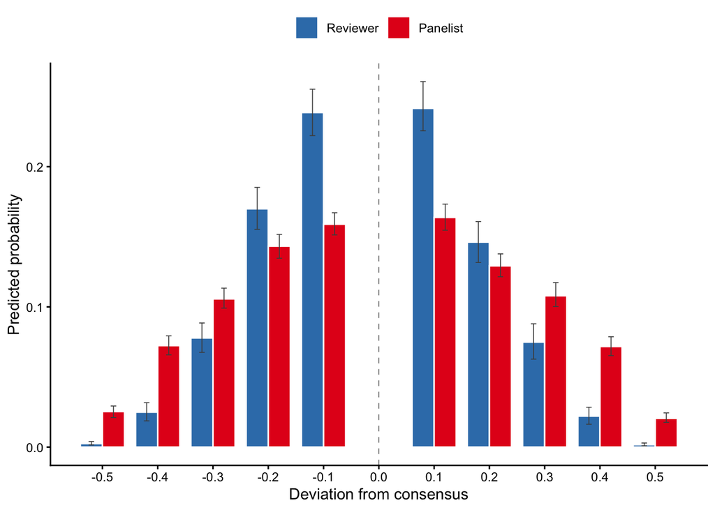

Figure 6: Predicted magnitude of deviation, by role

These differences in predicted probabilities for deviations of different magnitudes can also be expressed as marginal effects in Figure 7:

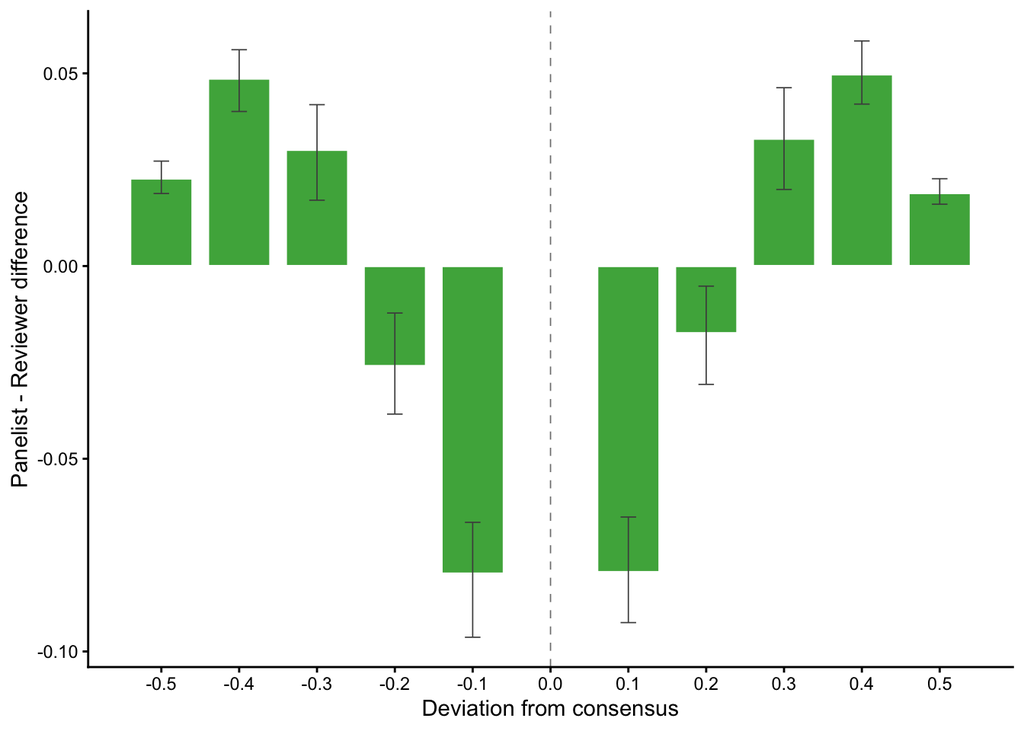

Figure 7: Marginal effects of job on the magnitude of deviations

## 3.4 Software

Bayesian throughout, via `brms` + `cmdstanr` (Stan backend), matching the conventions in our other multilevel work. `marginaleffects` for posterior contrasts; models cached to `code/fits/` and deliberately re-fit (not silently reused) whenever formula or data change.

# 4 Extending to Aim 2: applicant characteristics

Since applicant gender and career stage will never be extractable – not even as CIHR’s own dummy data – this simulation is the only pre-deployment test that code touching those variables gets. We added them as **application-level** attributes (one value per application, like consensus score, not per member) to a new, separate simulation script (`code/ror-sim-aim2.R`) rather than growing the Aim 1 script further – see “A note on simulation architecture” below.

Critically, we didn’t just add *main* effects of gender/career stage. Aim 2’s actual question is whether the *engagement/expertise effect on deviation* differs by applicant characteristic – which requires an **interaction** term to exist in the generating process, or there’s nothing for the fitted model to recover.

**code/ror-sim-aim2.R – applicant-level additions**

```r
# applicant-level main effects (modest -- not the effects of interest)
g1       =  0.1   # applicant gender = female
c1       = -0.1   # applicant career stage = early

# Aim 2's actual target: does the reviewer-engagement / expertise effect
# on P(deviate) differ by applicant gender / career stage? Baked in large
# on purpose so we can confirm the two-part model machinery actually
# recovers a real interaction, not just a real main effect.
i_panelist_female     =  0.5  # job(panelist) x gender(female)
i_expnone_earlycareer =  0.6  # exp(none) x career_stage(early)

data <- data |>
  mutate(
    p_dev = plogis(a0 + (a1 * panelist) + (a2 * exp_med) +
      (a3 * exp_low) + (a4 * exp_none) +
      (g1 * female) + (c1 * early_career) +
      (i_panelist_female * panelist * female) +
      (i_expnone_earlycareer * exp_none * early_career)),
    deviated = rbinom(n(), 1, p_dev)
    # ... deviation magnitude drawn the same way as Aim 1; applicant
    # terms are deliberately left out of the magnitude part, consistent
    # with the Aim 1 finding above that signal lives in whether someone
    # deviates, not in the average size of the deviation
  )
```

**To be clear about what these numbers are and aren’t:** they are chosen to be large enough to detect cleanly in a simulation of this size, not estimates – or even guesses – about the true magnitude or even direction of any real effect in CIHR review. The goal is purely to confirm our statistical machinery would notice an interaction if the real data contained one.

```r
d2 <- read_csv(here("data", "sim-aim2-data.csv"), show_col_types = FALSE)

m_aim2 <- glm(deviated ~ job * gender + exp * career_stage,
  data = d2, family = binomial())

coefs <- summary(m_aim2)$coefficients
coefs[grepl(":", rownames(coefs)), ] |>
  as_tibble(rownames = "term") |>
  tt(digits = 3)
```

Aim 2: interaction coefficients recovered from the simulated data (n = 18,000)

| term | Estimate | Std. Error | z value | Pr(>\|z\|) |
| --- | --- | --- | --- | --- |
| jobreviewer:gendermale | 0.571 | 0.0933 | 6.12 | 0.000000000933 |
| explow:career_stageestablished | 0.26 | 0.1228 | 2.12 | 0.034154693615 |
| expmed:career_stageestablished | 0.253 | 0.1281 | 1.97 | 0.048458324937 |
| expnone:career_stageestablished | -0.43 | 0.1195 | -3.6 | 0.00032331474 |

**Not yet built:** Aim-2-specific versions of `code/ror-analysis-deviate-model.R`/`ror-analysis-magnitude-model.R` that actually include these interaction terms in the `brm()` formulas. The simulation is ready; the model scripts that would be tested against it aren’t written yet.